# Tommaso Biganzoli

##### Inspecting influential points

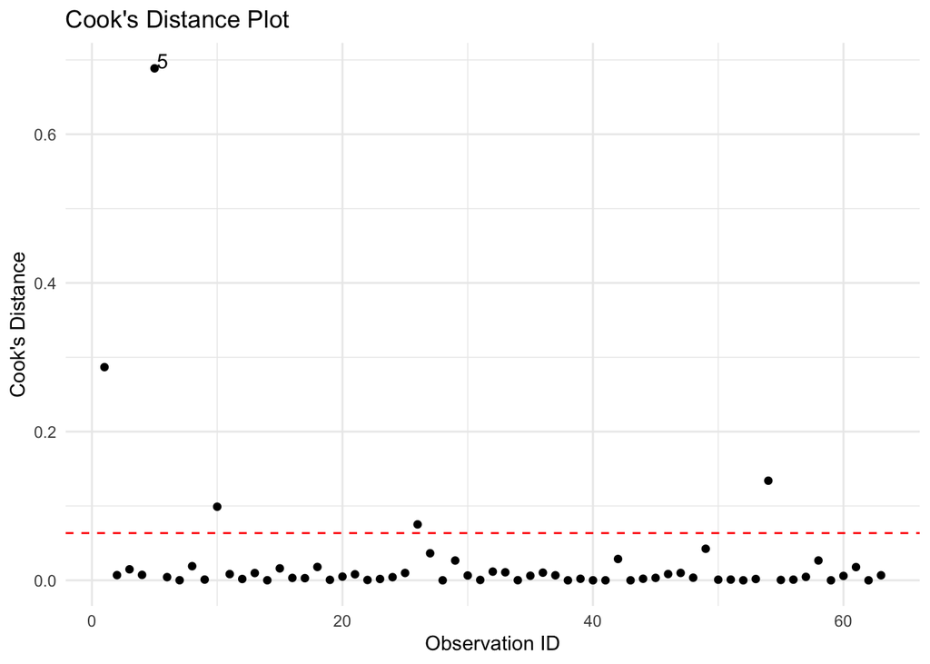

Figure 8 : *From the graph we can see from the y-axis the value of the Cook Distance, while from the x-axis, we can see the distribution of each observation*.

##### Inspecting possible high-leverage points

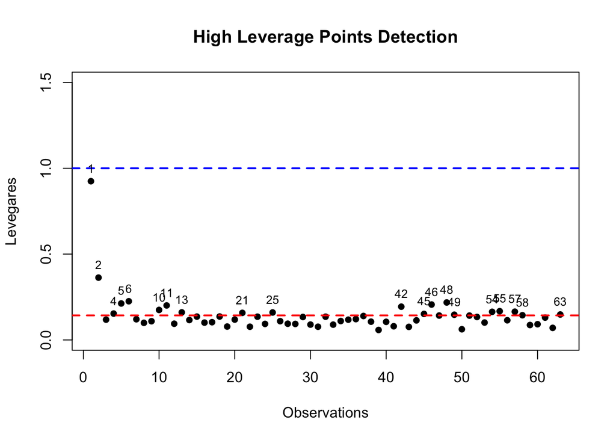

Figure 9 : *From the figure above we can see on the y axys the value of the leverage that indicates how far an observation is from its average, and on the x-axis the distribution of the observations*.

#### Trying to improve my model

###### Isolating the observation n^5

```r
PGATour[5, ]
```

```
## # A tibble: 1 × 13
##   Name          Rounds   Strks ScoreAVG Sponsor   GIR GreensHIT Earnings  RelPar
##   <chr>          <dbl>   <dbl>    <dbl> <fct>   <dbl>     <dbl>    <dbl>   <dbl>
## 1 Scottie Sche…   10.9 -0.0662    -1.45 Callaw…  1.16      86.7   1.18e7 -0.0640
## # ℹ 4 more variables: AVGPutting <dbl>, DrivAccuracy <dbl>, Country <fct>,
## #   AVGDrivDistance <dbl>
```

We can see that this is an unusual observation, as Scottie Scheffler is the player who won the ranking in the WGR, and therefore a value I expected. Studying the different methods to manage this size taken as outlier, there would be the transformation of the variable with the logarithmic function. Having negative data in my dataset, however, before we could use this function properly we would have to make further changes to our variables, such as the module, or other mathematic operations that would do nothing but lose information and variability to our regression analysis. The goal of the PGATour coaches in analyzing these statistics, and therefore mine, is not to keep in mind anomalous values of the winners of the ranking, which in most cases are short-lived phenomena, but rather to found a long-term training strategy. For the reasons listed above, for the purposes of my analysis, the least “harmful” decision is to remove observation 5 from my dataset. As for the other unusual observations, observation 1 and 2, they have high leverage, one way to reduce their impact would be to try to record observations close to them, so they would not be far away, in the space of regressors. In general the leverage points are not too bad, for now I decide to keep them in my dataset, aware that if any problems arose during my analysis, related to the presence of these, I can consider eliminating them. Regarding instead the influential points , as we see from the diagram of figure 8, none of them exceeds the canonical value of D=1, and therefore none of them is considered “harmful” for our dataset.

##### Considerations on heteroschedasticity

In trying to overcome the slight problem of nonconstant variances of the residues, I tried several transformations of the variables, which while slightly improving the variances, All they did was add computational complexity and find unusable models for the primary objective of my regression. I also tried to insert weights with WLS, but my model had practically no difference with the starting model. Since this is a slight heteroschedasticity problem, and for the purpose of my analysis has little relevance, I decided to accept it as it was.

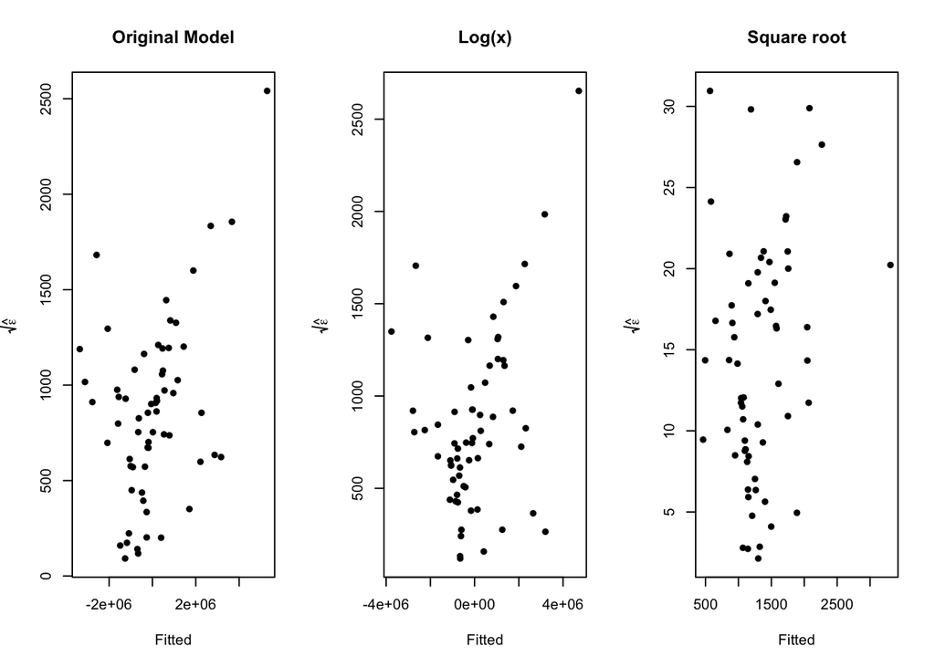

Figure 10 : *Below I selected the two best transformations I tried to apply to my data compared to my model without mathematical transformations.As we can see, there are no significant differences in the violated homoschedasticity hypothesis*.